# Report project number 1

Sciper 359523

2023-02-21

## 1. Introduction

Snow particle size is a critical feature used to model and understand the dynamics of avalanches, particularly large powder-snow avalanches that behave like fast-moving clouds down mountainsides [1]. The sedimentation velocity, which is highly influenced by particle size, plays a significant role in the dynamic of turbulent dilute suspension avalanches [1]. Accurate modeling of sedimentation velocity is crucial, as errors in size estimation can lead to 10x greater errors in velocity estimation.

In this report, I analyze a dataset of snow particle sizes obtained from a PhD student at the Laboratory of Cryospheric Sciences at EPFL. The dataset includes the number of particles in each size category, which is the most important feature for the analysis. I begin by performing exploratory data analysis to gain insights into the dataset and create a preliminary model. I then enhance this model using local optimization. Finally, I assess the model’s quality by performing parametric bootstrap analysis.

## 2. Data Characteristics

The outcome of interest is the variable *retained* which is the fraction of particles belonging to each diameter bin. The other available variables are

- The startpoint of the bin,
- The endpoint of the bin,
- The number of particles detected,

This study aims to simulate snowflake diameters that accurately reflect the data, in order to investigate the aeolian transport of snow.

*Figure 1* displays the percentage of particles in each bin relative to the bin length, with the distribution plotted according to the bin startpoint. The figure suggests that the data can be described by a mixture of log-normal distributions, with two visible distinct peaks. The bin interval lengths are different so I divide my initial proportions by the interval length in order to accurately represent the distribution.

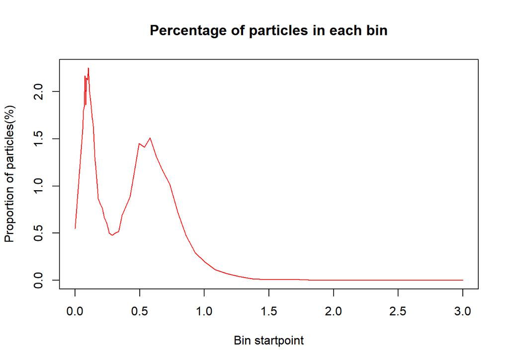

Figure 1: Percentage of particles in each bin

## 3. Model fitting

After identifying that the data may be distributed as a mixture of two log-normal distributions, the next step is to evaluate the parameters for the density function:

$f(x) = p \frac{1}{x \sigma_1 \sqrt{2\pi}} e^{-\frac{(\ln x - \mu_1)^2}{2\sigma_1^2}} + (1-p) \frac{1}{x \sigma_2 \sqrt{2\pi}} e^{-\frac{(\ln x - \mu_2)^2}{2\sigma_2^2}}$

To evaluate the five parameters $p$, $\mu_1$, $\sigma_1$, $\mu_2$, and $\sigma_2$, I will use the Expectation-Maximization (EM) algorithm, which is a widely used iterative method for estimating the parameters of statistical models with latent variables.

In the first step of the EM algorithm, I will initialize the parameters and estimate the posterior distribution of the latent variables. In the second step, I will update the parameters using the expected values of the latent variables computed in the first step. I will repeat these two steps until convergence.

### EM algorithm

I implement hereafter an EM-algorithm taking as initialization parameters

$\mu_1 = 0.25$, $\sigma_1 = 0.75$, $\mu_2 = 0.25$, $\sigma_2 = 0.5$, $p = 0.5$

$\epsilon = 0.001$ will constitute the threshold such that I stop the algorithm when the difference in the log-likelihoods is under $\epsilon$.

The EM algorithm components are obtained with the following reasoning. Let $X_1,\ldots,X_N$ be i.i.d. from
$$f_{mixture}(x) = p
\varphi_{lognormal,\mu_1,\sigma_1^2}(x) + (1-p)
\varphi_{lognormal,\mu_2,\sigma_2^2}(x)$$
where
$$\varphi_{lognormal,\mu_1,\sigma_1^2}(x)$$
corresponds to the density of the lognormal distribution with parameters $\mu_1$ and $\sigma_1^2$. The log likelihood doesn’t have a good form so I draw $Zn = \mathbb{I}_{\left[X_n \text{ drawn from }\varphi_{\mu_2,\sigma_2^2}\right]} \sim \mathrm{Bern}(p)$ iid and independent of the $X_i$. One can rewrite the likelihood as
$$\ell_{comp}(\theta) = \sum_{n=1}^N \left\{ (1-Z_n)\left[ \log
\varphi_{lognormal, \mu_1,\sigma_1^2}(X_n) + \log(p) \right] + Z_n\left[
\log \varphi_{lognormal, \mu_2,\sigma_2^2}(X_n) + \log(1-p) \right]
\right\}$$

One can then define
$$E_{\theta^{(l-1)}}\big[\ell_{comp}(\theta) \big| X_1,\ldots,X_n\big] =
P(Z_n=1|X_n) = \frac{P(X_n|Z_n=1) P(Z_n=1)}{P(X_n)} =: \gamma_n^{(l-1)}$$

The M-step allows us to update the parameters in the following way
$$\begin{split}
p^{(l)} &= N^{-1} \gamma, \quad \text{where} \quad \gamma =
\sum_{n=1}^N \gamma^{(l-1)}_n \\
\mu_1^{(l)} &= \gamma^{-1} \sum_{n=1}^N \big(\gamma^{(l-1)}_n\big)
log(X_N) \\
(\sigma_1^2)^{(l)} &= \gamma^{-1} \sum_{n=1}^N
\big(\gamma^{(l-1)}_n\big) \big(log(X_n) - \mu_1^{(l)} \big)^2 \\
\mu_2^{(l)} &= (N-\gamma)^{-1} \sum_{n=1}^N (1-\gamma^{(l-1)}_n)
log(X_N) \\
(\sigma_2^2)^{(l)} &= (N-\gamma)^{-1} \sum_{n=1}^N
(1-\gamma^{(l-1)}_n) \big(log(X_n) - \mu_2^{(l)} \big)^2 \\
\end{split}$$

Before doing my EM-algorithm, I do some jittering. I simulate points uniformly in the different diameters intervals in a proportion according to the percentage of particles in each bin. I simulate 705044 points which corresponds to the total number of particles detected.

The parameters that I obtain are the following $\mu_1 = - 0.43$ $\mu_2 = - 1.71$ $\sigma_1 = 0.26$ $\sigma_2 = 0.96$ $p = 0.54$

With the parameters I obtained, I generate *Figure2* which shows the fitted model and our data. The red curve represents the data we aim at modeling and the black one represents our model estimation. I will keep this convention throughout the report.

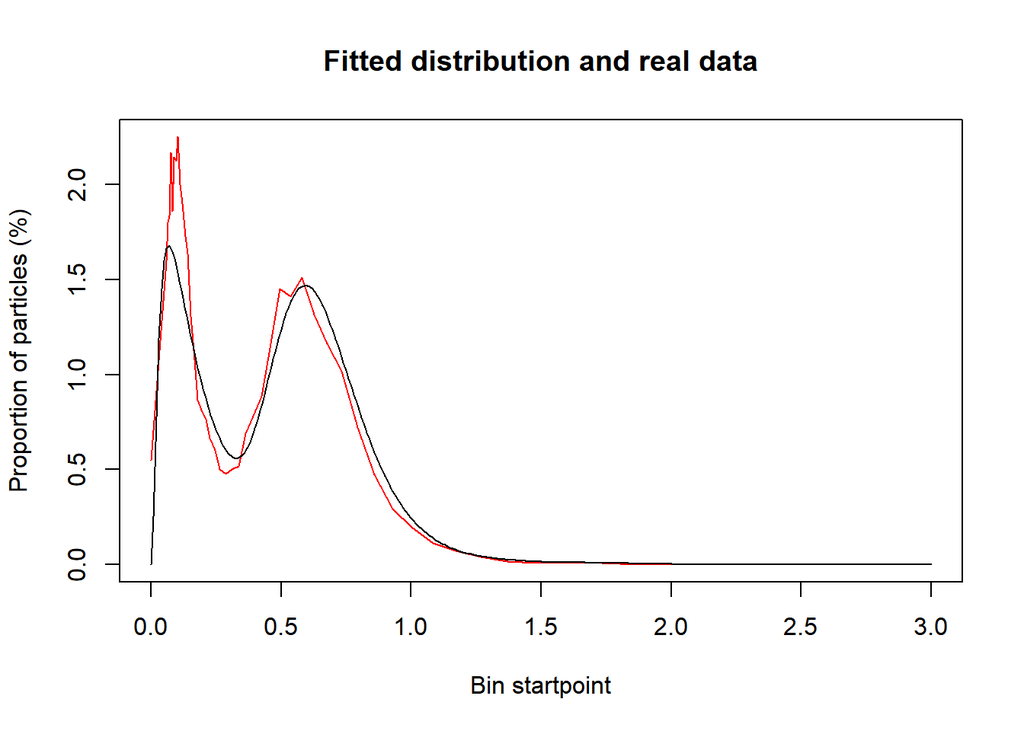

Figure 2: Fitted distribution

Although the density I obtained approximately fits the data, it is not fully satisfying because the left peak is under-estimated. To improve the fit, we consider using local optimization techniques.

### Stability of the EM algorithm solution and local modifications

To evaluate the stability of my EM-algorithm solutions, I want to see how our estimated density behaves when I slightly modify one or several parameters. I define an $\epsilon = 0.05$ that I add or subtract to my parameters to see to what extent this changes the model. The different setups are the following

| Setup | mean 1 | mean 2 | standard deviation 1 | standard deviation 2 | probability |
| --- | --- | --- | --- | --- | --- |
| Setup 1 | $\mu_1$ | $\mu_2$ | $\sigma_1$ | $\sigma_2$ | $p$ |
| Setup 2 | $\mu_1 + \epsilon$ | $\mu_2+\epsilon$ | $\sigma_1+\epsilon$ | $\sigma_2+\epsilon$ | $p+2\epsilon$ |
| Setup 3 | $\mu_1 - \epsilon$ | $\mu_2-\epsilon$ | $\sigma_1-\epsilon$ | $\sigma_2-\epsilon$ | $p+2\epsilon$ |
| Setup 4 | $\mu_1 - \epsilon$ | $\mu_2+\epsilon$ | $\sigma_1+\epsilon$ | $\sigma_2+\epsilon$ | $p-\epsilon$ |
| Setup 5 | $\mu_1 + \epsilon$ | $\mu_2-\epsilon$ | $\sigma_1$ | $\sigma_2$ | $p+2\epsilon$ |
| Setup 6 | $\mu_1 - \epsilon$ | $\mu_2+\epsilon$ | $\sigma_1$ | $\sigma_2$ | $p+\epsilon$ |

where $\mu_1$, $\sigma_1$, $\mu_2$, $\sigma_2$ and $p$ are the parameters estimated with the EM algorithm. In other words, setup 1 uses the parameters from the EM algorithm. The other plots are then to be compared to this reference setup.

The results are given by *Figure3*. The obtained graphs do not seem to have improved compared to the EM-algorithm. Thus, I am going to optimize the likelihood in order to find better parameters.

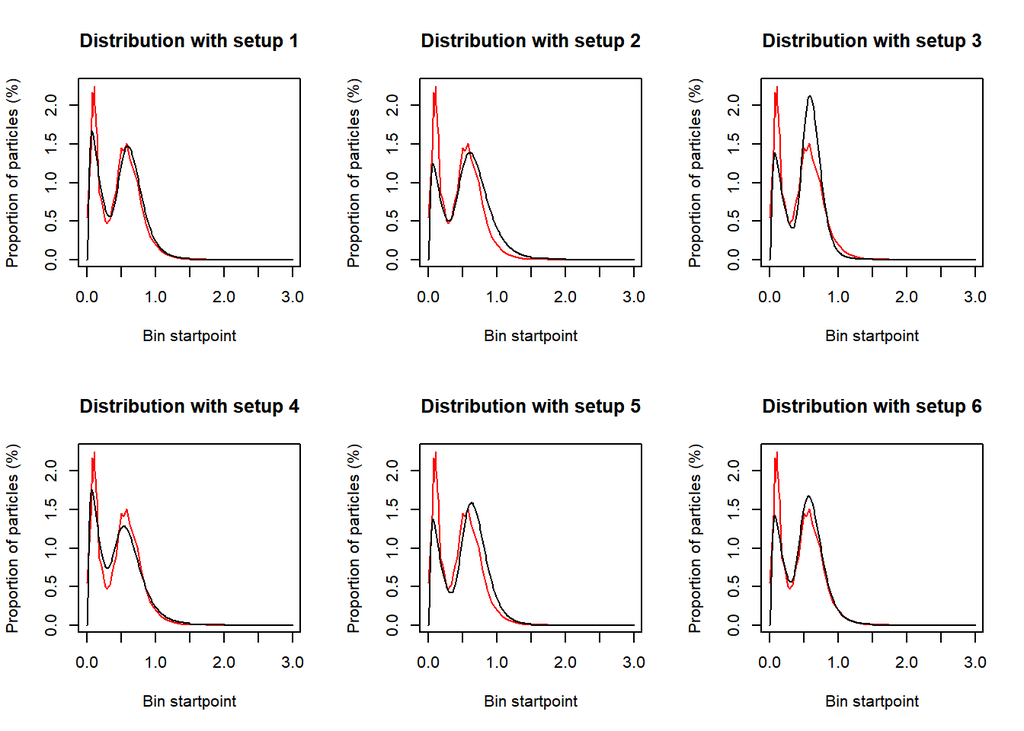

Figure 3: Local modification of parameters

### Local optimization

Local optimization seeks to find the values of the parameters that minimize a given objective function, by searching the parameter space around an initial point. I use the r function *optim* to estimate my parameters starting from the ones estimated with the EM-algorithm.

With local optimization, the new obtained parameters are $mu_1 = -0.45$ $\sigma_1 = 0.30$, $mu_2=-2.01$, $sigma_2 = 0.60$, $p=0.65$

*Figure4* represents in red the data distribution, in black the one with parameters estimated with the EM-algorithm and in blue the one with the optimized parameters. The blue curve fits the data better than the black one which indicates the optimization is successful.

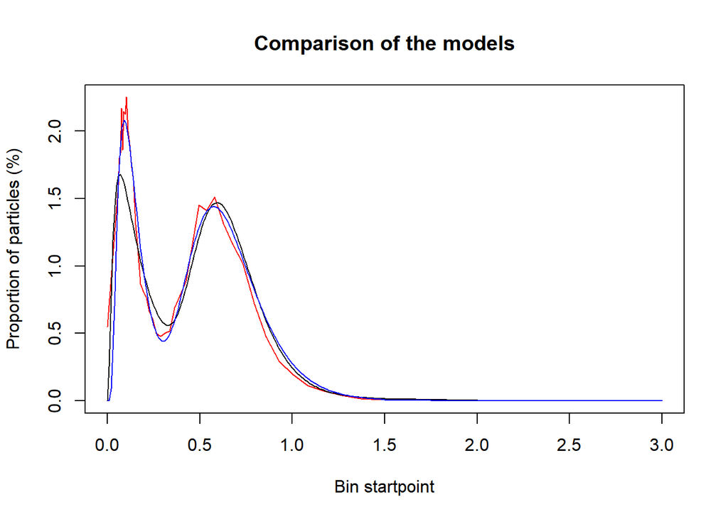

Figure 4: Comparison of the distributions with the different estimated parameters

### Parametric bootstrap

In this section, a parametric bootstrap algorithm [2] is implemented to assess if the data truly comes from a mixture of lognormal distributions. The purpose of the algorithm is to sample from the fitted distribution using the estimated parameters, and then calculate the Kolmogorov-Smirnov statistic, denoted by $T$. To do so, I sample from the fitted distribution with the estimated parameters. I use the Kolmogorov-Smirnov statistic $T = \sup_x \Big| \widehat{F}_N(x) - F_\widehat{\lambda}(x) \Big|$, where one assumes that under $H_0$ the estimated parameters $\widehat{\lambda}$ are consistent to the real parameters ${\lambda}_0$.

The null hypothesis I want to test is thus

$H_0:F \in \mathcal{F} = \{ F_\lambda \mid \lambda \in \Lambda \}$ against $H_1: F \notin \mathcal{F}$ if $\mathcal{F}=\{F_0 \}$

To execute the parametric bootstrap algorithm, the procedure outlined in [2] is followed. Resamples are generated, and the parameters are estimated on these new resamples. The empirical distribution function is then calculated, allowing for the calculation of the Kolmogorov-Smirnov statistic. The p-value of the test can then be computed using the T statistic.

The obtained p-value is of 1 so I don’t reject the null hypothesis. In other words, one concludes that the hypothesis that our data comes from a mixture of two lognormal distributions is not rejected.

## 4. Discussion and conclusion

Throughout this project, I have focused on the mixture of two lognormal distributions as it fits the data well, and my parametric bootstrap algorithm did not reject it. The p-value of 1 is doubtable but explained by the fact that I only did 10 bootstrap resamples due to the computational cost of my algorithms. Doing it for more than 5000 times gives a p-value of 0.997 which gives a very high level of confidence about the fact that the distribution comes from a mixture of two lognormal distributions. Estimating the parameters of this distribution is challenging, as there is no closed-form formula for the maximum likelihood estimate. I have used a combination of the EM algorithm and local optimization to estimate the parameters, which resulted in a slightly improved fit of the model. The initial parameters for the EM algorithm were chosen based on descriptive statistics and provided a satisfactory starting point for the optimization.

To conclude, this work enables now to simulate diameters accurately using the mixture of two lognormal distributions following this equation

$f(x) = p \frac{1}{x \sigma_1 \sqrt{2\pi}} e^{-\frac{(\ln x - \mu_1)^2}{2\sigma_1^2}} + (1-p) \frac{1}{x \sigma_2 \sqrt{2\pi}} e^{-\frac{(\ln x - \mu_2)^2}{2\sigma_2^2}}$

with the parameters

$\mu_1 = -0.45$ $\sigma_1 = 0.30$, $\mu_2=-2.01$, $\sigma_2 = 0.60$, $p=0.65$

## 5. References

[1] https://hal.inria.fr/inria-00405714/document \

[2] https://github.com/TMasak/StatComp/blob/master/Notes/10_Bootstrap.Rmd, section ‘Parametric bootstrap and goodness of fit’ \

[3]https://github.com/TMasak/StatComp/blob/master/Slides/13_BayesComp.pdf